# Análisis de la distribución espacial de Viviendas de material Precario (AGIP) y Hogares con viviendas de calidad deficitaria (CENSO 2010)

Bárbara Pasik y Soledad Tiranti

28/6/2019

- Paquetes de R Studio empleados en el trabajo

```r
library(tidyverse)
library(sf)
```

> INTRODUCCION

El objetivo de este trabajo es analizar la distribución espacial, en la Ciudad de Buenos Aires, de las viviendas identificadas como “VIVIENDAS DE MATERIAL PRECARIO”, según el padron de AGIP por el cual tributan el inmobiliario y ABL en relación a la distribución de los hogares que presentan viviendas de calidad deficitaria, según el Censo Nacional de Población y Viviendas del año 2010. Se busca determinar si existe un patrón de distribución similar entre ambos casos.

> DESARROLLO

> Parte 1: Distribución espacial de Viviendas de material precario (AGIP)

En esta parte del trabajo se emplearon los siguientes dataset:

- 2 dataset en formato *csv:
1. **item.csv**: contiene la información de los destinos constructivos de las parcelas de la CABA, según el padrón de AGIP, en base al cual tributan el impuesto inmobiliario y ABL (alumbrado, barrido y limpieza).
2. **mat.csv**: presenta en su estructura la identificación de la Partida Matriz (identificación unívoca de una parcela) con su nomenclatura catastral, sección, manzana y parcela (smp).
- 2 archivos con información espacial:
1. **manzanas.shp**: archivo shapefile que contiene los límites de las manzanas catastrales de la Ciudad de Buenos Aires.
2. **barrios.geojson**: capa geográfica que presenta los límites de los barrios de la Ciudad de Buenos Aires.

**Paso 1: Apertura, limpieza y visualización de datasets**

Comenzamos con el dataset “mat.csv”

```r
mat <- read.csv2("DATOS_TP/TABLAS/mat.csv")
```

Visualizamos sus primeros 6 registros:

```r
head(mat)
```

```
##   MATRIZ SECCION MANZANA PARCELA
## 1      4      77     147    023B
## 2      7      77     147     019
## 3     12      77     147     013
## 4     16      77     147     009
## 5     18      77     147     007
## 6     20      77     147     005
```

Luego añadimos en la tabla dos nuevos campos: uno que combina la información de sección y manzana (sm) y otro que une la información de sección, manzana y parcela (smp). Estos campos fueron creados ya que serán útiles más adelante para hacer operaciones de join entre datasets.

```r
mat <- mat %>%
  mutate(SECCION = paste(0, SECCION, sep = ""), #agrego 0 a la informacion de sección
         sm = paste(SECCION, MANZANA, sep = "-"),
         smp = paste(SECCION, MANZANA, PARCELA, sep = "-"))
```

```r
head(mat)
```

```
##   MATRIZ SECCION MANZANA PARCELA      sm          smp
## 1      4     077     147    023B 077-147 077-147-023B
## 2      7     077     147     019 077-147  077-147-019
## 3     12     077     147     013 077-147  077-147-013
## 4     16     077     147     009 077-147  077-147-009
## 5     18     077     147     007 077-147  077-147-007
## 6     20     077     147     005 077-147  077-147-005
```

Luego continuamos con el dataset “item.csv”

```r
item <- read.csv2("DATOS_TP/TABLAS/item.csv")
```

Corregimos de la tabla el campo AÑO_CONST para que la información del mismo se muestre con formato de tipo “fecha” y no como números decimales.

```r
item <- item %>%
  mutate(AÑO_CONST = AÑO_CONST * 1000)
```

```r
head(item)
```

```
##   MATRIZ ITEM SUPERFICIE                        DESTINO CATEGORIA EST_ITEM
## 1      4    1        634         VIVIENDA MULTIFAMILIAR         E    Bueno
## 2      4    2        139         VIVIENDA MULTIFAMILIAR         D    Bueno
## 3      4    3        216         VIVIENDA MULTIFAMILIAR         D    Bueno
## 4      4    4        426     LOCALES, GALERIAS, CAJEROS         E    Bueno
## 5      4    5        454     LOCALES, GALERIAS, CAJEROS         E    Bueno
## 6      7    1        183 VIV.UNIFAMILIAR Y CASAS VELAT.         D    Bueno
##   AÑO_CONST
## 1      1950
## 2      1960
## 3      1950
## 4      1950
## 5      1960
## 6      1920
```

**Paso 2: Filtro-selección de registros y operaciones Join entre datasets**

Realizamos un filtro de registros que se corresponden con el DESTINO: “VIVIENDA MATERIAL PRECARIO” mediante el comando “filter” en la tabla “item”.A la nueva tabla generada le designamos el nombre: **“item_vmatp”**

```r
item_vmatp <- filter(item, DESTINO == "VIVIENDA MATERIAL PRECARIO")
```

```r
head(item_vmatp)
```

```
##   MATRIZ ITEM SUPERFICIE                    DESTINO CATEGORIA EST_ITEM
## 1    650    3         54 VIVIENDA MATERIAL PRECARIO         E    Bueno
## 2    796    5          8 VIVIENDA MATERIAL PRECARIO         F    Bueno
## 3    895    2         30 VIVIENDA MATERIAL PRECARIO         E    Bueno
## 4   1225    4         21 VIVIENDA MATERIAL PRECARIO         E    Bueno
## 5   1226    2         38 VIVIENDA MATERIAL PRECARIO         E    Bueno
## 6   1240    6         25 VIVIENDA MATERIAL PRECARIO         E  Regular
##   AÑO_CONST
## 1      1960
## 2      1970
## 3      1970
## 4      1970
## 5      1960
## 6      1970
```

Luego se realizaron 2 operaciones join:

1. JOIN N°1: entre “item_vmatp” y “mat” (mediante el campo común denominado MATRIZ). Luego del join, cada registro obtuvo su identificación catastral (sm y smp) y se generó una nueva tabla denominada “mat_vmatp”.
2. JOIN N°2: join entre “mat_vmatp” con el archivo “manzanas.shp”, mediante el campo común “sm”. De esta manera se logró que cada registro tenga su información de localización espacial (coordenadas) para luego poder visualizar en un mapa la distribución de las viviendas de material precario.

JOIN N°1: “item_vmatp” con “mat”:

```r
"mat_vmatp" <- left_join(item_vmatp, mat)
head(mat_vmatp)
```

```
##   MATRIZ ITEM SUPERFICIE                    DESTINO CATEGORIA EST_ITEM
## 1    650    3         54 VIVIENDA MATERIAL PRECARIO         E    Bueno
## 2    796    5          8 VIVIENDA MATERIAL PRECARIO         F    Bueno
## 3    895    2         30 VIVIENDA MATERIAL PRECARIO         E    Bueno
## 4   1225    4         21 VIVIENDA MATERIAL PRECARIO         E    Bueno
## 5   1226    2         38 VIVIENDA MATERIAL PRECARIO         E    Bueno
## 6   1240    6         25 VIVIENDA MATERIAL PRECARIO         E  Regular
##   AÑO_CONST SECCION MANZANA PARCELA      sm         smp
## 1      1960     077     133     012 077-133 077-133-012
## 2      1970     077     137     031 077-137 077-137-031
## 3      1970     077     125     025 077-125 077-125-025
## 4      1970     077     121     005 077-121 077-121-005
## 5      1960     077     121     004 077-121 077-121-004
## 6      1970     077     106     019 077-106 077-106-019
```

Como resultado final obtuvimos que de 140.986 destinos constructivos para toda la Ciudad de Buenos Aires, 1343 se corresponden con VIVIENDAS DE MATERIAL PRECARIO, según AGIP.

Antes de realizar el JOIN N°2 agrupamos por sm los registros de viviendas (identicados por sm luego del join) mediante el comando “Group_by” en la tabla “mat_vmatp” y luego contabilizamos la cantidad de viviendas por manzana catastral mediante el comando “Summarise”.

Aplicamos la herramienta GROUP_BY por “sm” en “mat_vmatp” y generamos una nueva tabla llamada **“sm_vmatp”**:

```r
sm_vmatp <- mat_vmatp %>%
  group_by(sm) %>%
  summarise(casos = n())
```

```r
head(sm_vmatp)
```

```
## # A tibble: 6 x 2
##   sm       casos
##   <chr>    <int>
## 1 01-053       1
## 2 010-067      2
## 3 010-094      1
## 4 010-099      1
## 5 010-102A     3
## 6 010-106      1
```

Se obtuvo de esta manera la cantidad de viviendas de material precario (campo “casos”) por manzana catastral. Resultó un total de 924 manzanas que presentan la categoria de vivienda de material precario.

JOIN N°2: entre “sm_vmatp” y el archivo “manzanas.shp” mediante el campo en común “sm”. Al archivo espacial resultante se lo denominó **“mza_vmatp”**.

Primero leímos el archivo espacial de manzanas catastrales:

```r
manzanas <- st_read("DATOS_TP/INFORMACION ESPACIAL/manzanas.shp")
head(manzanas)
```

```
## Simple feature collection with 6 features and 4 fields
## geometry type:  POLYGON
## dimension:      XY
## bbox:           xmin: -58.43173 ymin: -34.63911 xmax: -58.41601 ymax: -34.63756
## epsg (SRID):    4326
## proj4string:    +proj=longlat +datum=WGS84 +no_defs
##   featid1 seccion manzana       sm                       geometry
## 1    8895     038     030  038-030 POLYGON ((-58.43173 -34.638...
## 2    8874     038    147B 038-147B POLYGON ((-58.42274 -34.637...
## 3    8867     038     048  038-048 POLYGON ((-58.43051 -34.637...
## 4    8862     038    147A 038-147A POLYGON ((-58.42202 -34.637...
## 5    8860     038     219  038-219 POLYGON ((-58.4172 -34.6383...
## 6    8841     038     066  038-066 POLYGON ((-58.42925 -34.637...
```

Luego realizamos el JOIN entre “manzanas” y “sm_vmatp”:

```r
"mza_vmatp" <- left_join(manzanas, sm_vmatp)
```

Exploramos el archivo shapefile resultante:

```r
head(mza_vmatp)
```

```
## Simple feature collection with 6 features and 5 fields
## geometry type:  POLYGON
## dimension:      XY
## bbox:           xmin: -58.43173 ymin: -34.63911 xmax: -58.41601 ymax: -34.63756
## epsg (SRID):    4326
## proj4string:    +proj=longlat +datum=WGS84 +no_defs
##   featid1 seccion manzana       sm casos                       geometry
## 1    8895     038     030  038-030    NA POLYGON ((-58.43173 -34.638...
## 2    8874     038    147B 038-147B    NA POLYGON ((-58.42274 -34.637...
## 3    8867     038     048  038-048    NA POLYGON ((-58.43051 -34.637...
## 4    8862     038    147A 038-147A    NA POLYGON ((-58.42202 -34.637...
## 5    8860     038     219  038-219    NA POLYGON ((-58.4172 -34.6383...
## 6    8841     038     066  038-066    NA POLYGON ((-58.42925 -34.637...
```

**Paso 3: mapeo de los resultados**

Para representar los resultados obtenidos en un mapa, leímos en primera instancia el archivo espacial “barrios.geojson”:

```r
barrios <- st_read("DATOS_TP/INFORMACION ESPACIAL/barrios.geojson")
```

Luego chequeamos el mapeo de la información de barrios de la ciudad:

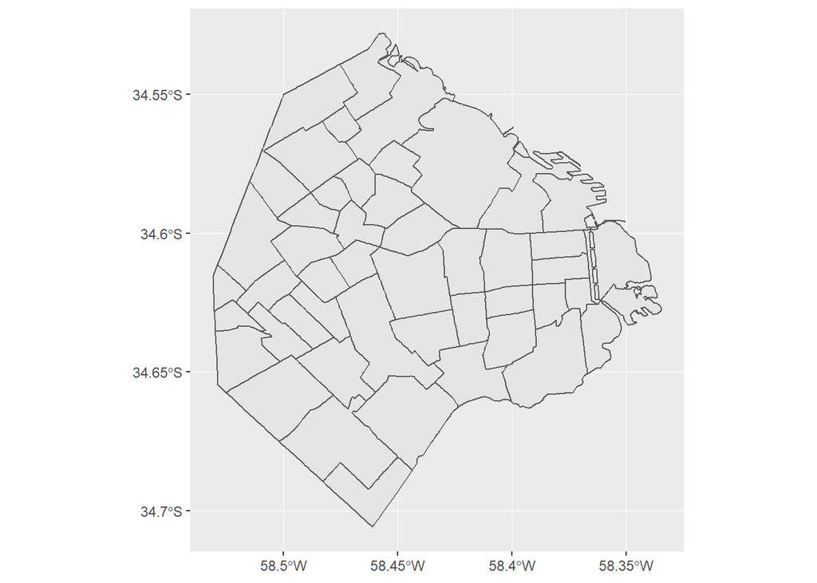

```r
ggplot() +
  geom_sf(data = barrios)
```

Antes de mapear la distribución de las viviendas de material precario en la ciudad según AGIP, realizamos una codificamos de la cantidad de casos de viviendas en una escala categórica para obtener una mejor visualización de la distribución espacial de las mismas:

```r
mza_vmatp <- mza_vmatp %>%
  mutate (precariedad = case_when (
    casos == 1 ~ "un caso",
    casos <= 5 ~ "hasta 5",
    casos <= 10 ~ "hasta 10",
    casos > 10 ~ "mayor a 10"))
```

```r
head(mza_vmatp)
```

```
## Simple feature collection with 6 features and 6 fields
## geometry type:  POLYGON
## dimension:      XY
## bbox:           xmin: -58.43173 ymin: -34.63911 xmax: -58.41601 ymax: -34.63756
## epsg (SRID):    4326
## proj4string:    +proj=longlat +datum=WGS84 +no_defs
##   featid1 seccion manzana       sm casos                       geometry
## 1    8895     038     030  038-030    NA POLYGON ((-58.43173 -34.638...
## 2    8874     038    147B 038-147B    NA POLYGON ((-58.42274 -34.637...
## 3    8867     038     048  038-048    NA POLYGON ((-58.43051 -34.637...
## 4    8862     038    147A 038-147A    NA POLYGON ((-58.42202 -34.637...
## 5    8860     038     219  038-219    NA POLYGON ((-58.4172 -34.6383...
## 6    8841     038     066  038-066    NA POLYGON ((-58.42925 -34.637...
##   precariedad
## 1        <NA>
## 2        <NA>
## 3        <NA>
## 4        <NA>
## 5        <NA>
## 6        <NA>
```

Observamos de la tabla anterior que existen muchos registros sin dato (NA). Como necesitamos trabajar solamente con aquellas manzanas que posean algÚn caso de vivienda de material precario, filtramos de la misma aquellos valores de tipo NA, dejando sólo los registros que poseen dato. Llamamos a esta nueva tabla **“mza_vmatp2”**.

```r
mza_vmatp2 <- filter(mza_vmatp, casos != "NA")
```

A continuación representamos en el mapa de barrios la ubicación de las viviendas de material precario según AGIP.

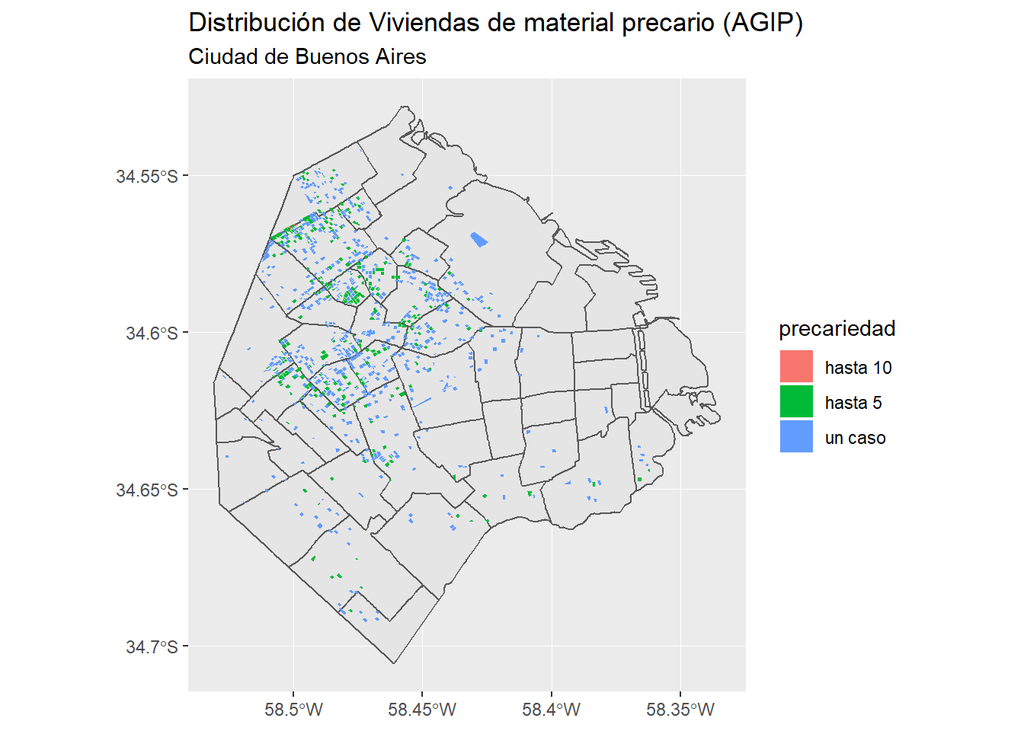

```r
ggplot() +
  geom_sf(data = barrios) +
  geom_sf(data = mza_vmatp2, aes(fill = precariedad), color=NA)  +
  labs(title = "Distribución de Viviendas de material precario (AGIP)",
         subtitle = "Ciudad de Buenos Aires")
```

> Parte 2: Distribución espacial de Hogares con viviendas de calidad deficitaria (Censo 2010, INDEC)

En esta segunda parte del trabajo empleamos el siguiente archivo:

**censo_2010.shp**: archivo espacial que contiene la información a nivel de radio censal de las variables analizadas en el censo 2010 que a continuación se detallan:

• SUP10: Superficie del radio censal (en hectáreas) • DENS10: Densidad poblacional (cantidad de personas por hectárea) • POB10: Cantidad de población en el radio censal • VIV10: Cantidad de viviendas en el radio censal • HOG10: Cantidad de hogares en el radio censal • HAC_HO10: Número de hogares hacinados en el radio censal • NBI10: Número de hogares con necesidades básicas insatisfechas • NBI_H10: Número de hogares hacinados • NO_VIV10: Número de hogares con viviendas de calidad deficitaria

**Paso 1: Exploramos el archivo del censo del año 2010:**

```r
CENSO <- st_read("DATOS_TP/INFORMACION ESPACIAL/censo_2010.shp")
head(CENSO)
```

```
## Simple feature collection with 6 features and 32 fields
## geometry type:  MULTIPOLYGON
## dimension:      XY
## bbox:           xmin: -58.53092 ymin: -34.64523 xmax: -58.46358 ymax: -34.53388
## epsg (SRID):    4326
## proj4string:    +proj=longlat +datum=WGS84 +no_defs
##       SUP10    DENS10 POB10 VIV10 HOG10 HAC_HO10  Z_AGUA10   Z_CLOA10
## 1 38.983150  12.67214   494   344   233 0.677326  99.14163 100.000000
## 2 12.184900  67.54261   823   346   308 0.890173 100.00000  98.051948
## 3 11.683500  52.29597   611   228   221 0.969298 100.00000  96.832579
## 4  6.806925  74.18915   505   224   195 0.870536 100.00000  99.487179
## 5 11.432690  40.23550   460   128   125 0.976563  99.20000   7.627119
## 6  7.302450 121.19220   885   310   260 0.838710 100.00000  99.610895
##    Z_GAS10   Z_NBI10  Z_NBIH10 Z_NVIV10  Z_NINO10 Z_NEDU10 Z_DESO10
## 1 98.71245  0.000000  0.000000 0.000000  0.000000  9.87395 6.730769
```

[output cut: 26 more lines]

Visualizamos los campos del archivo CENSO (se visualizan en cada campo los nombres de las variables mencionadas anteriormente)

```r
names(CENSO)
```

```
##  [1] "SUP10"    "DENS10"   "POB10"    "VIV10"    "HOG10"    "HAC_HO10"
##  [7] "Z_AGUA10" "Z_CLOA10" "Z_GAS10"  "Z_NBI10"  "Z_NBIH10" "Z_NVIV10"
## [13] "Z_NINO10" "Z_NEDU10" "Z_DESO10" "Z_OCUP10" "Z_INMI10" "Z_NTEN10"
## [19] "AGUA10"   "CLOAC10"  "GAS10"    "NBI10"    "NBI_H10"  "NO_VIV10"
## [25] "NO_INO10" "NO_EDU10" "DESOC10"  "OCUP10"   "INMIG10"  "NO_TEN10"
## [31] "X"        "Y"        "geometry"
```

**Paso 2: selección de campos**

De la tabla de atributos de “CENSO”" realizamos la selección de la variable **“NO_VIV10”** (Número de hogares con viviendas de calidad deficitaria) mediante el comando “select”:

```r
CENSO_NO_VIV10 <- select(CENSO, NO_VIV10)
```

Verificamos que haya sido seleccionado de la tabla de atributos el campo que necesitabamos:

```r
names(CENSO_NO_VIV10)
```

```
## [1] "NO_VIV10" "geometry"
```

```r
head(CENSO_NO_VIV10)
```

```
## Simple feature collection with 6 features and 1 field
## geometry type:  MULTIPOLYGON
## dimension:      XY
## bbox:           xmin: -58.53092 ymin: -34.64523 xmax: -58.46358 ymax: -34.53388
## epsg (SRID):    4326
## proj4string:    +proj=longlat +datum=WGS84 +no_defs
##   NO_VIV10                       geometry
## 1        0 MULTIPOLYGON (((-58.465 -34...
## 2        0 MULTIPOLYGON (((-58.50017 -...
## 3        0 MULTIPOLYGON (((-58.52236 -...
## 4        0 MULTIPOLYGON (((-58.52291 -...
## 5        3 MULTIPOLYGON (((-58.53089 -...
## 6        2 MULTIPOLYGON (((-58.52917 -...
```

**Paso 3: mapeo de la información**

Se realizó, a modo de chequeo visual de la información, el mapeo del número de hogares con viviendas de calidad deficitaria según el censo de 2010.

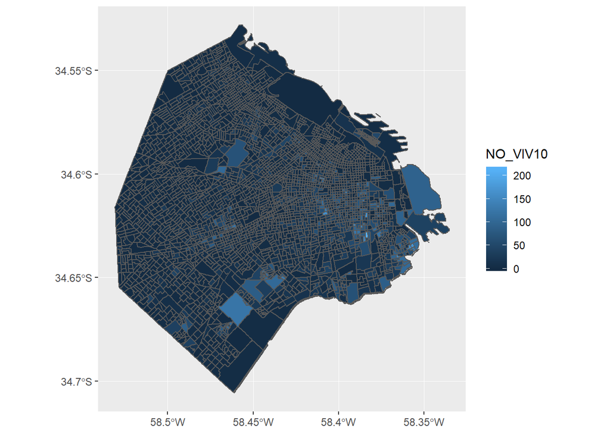

```r
ggplot() +
  geom_sf(data = CENSO_NO_VIV10, aes(fill=NO_VIV10))
```

Observamos que el mapeo no fue del todo óptimo para poder ser analizada la información censal; en consecuencia se decidió llevar a cabo una categorización de los datos.

Realizamos un histograma para visualizar la distribución de los datos y luego poder realizar una categorización de los mismos (y en consecuencia un mapeo más óptimo de la información).

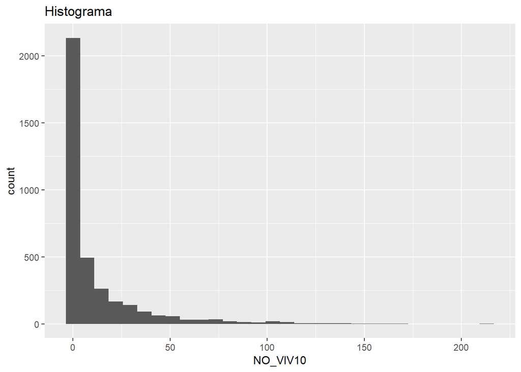

```r
ggplot(CENSO_NO_VIV10) +
    geom_histogram(aes(x = NO_VIV10)) +
  labs(title = "Histograma")
```

Convertimos la cantidad de hogares con vivienda de calidad deficitaria en una variable categórica (factor) con orden:

```r
CENSO_NO_VIV10 <- CENSO_NO_VIV10 %>%
  mutate(cantidad_hogares = case_when(
    NO_VIV10 == 0 ~ "ningún hogar",
    NO_VIV10 <= 50  ~ "1 a 50 hogares",
    NO_VIV10 <= 100 ~ "51 a 100 hogares",
    NO_VIV10 <= 150 ~ "101 a 150 hogares",
    NO_VIV10 <= 215 ~ "hasta 215 hogares" ))
```

```r
CENSO_NO_VIV10 <- CENSO_NO_VIV10 %>%
  mutate(cantidad_hogares = factor(cantidad_hogares,
                                   levels = c("ningún hogar",
                                              "1 a 50 hogares",
                                              "51 a 100 hogares",
                                              "101 a 150 hogares",
                                              "hasta 215 hogares"),
                                   ordered = TRUE))
```

Luego mapeamos los resultados:

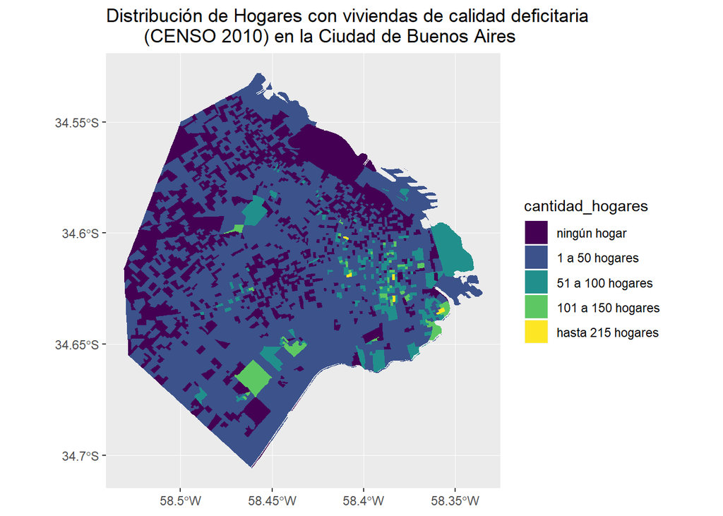

```r
ggplot() +
  geom_sf(data = CENSO_NO_VIV10, aes(fill = cantidad_hogares), color = NA) +
  labs(title = "Distribución de Hogares con viviendas de calidad deficitaria
       (CENSO 2010) en la Ciudad de Buenos Aires")
```

**Parte 3: Análisis de la distribución de las viviendas de material precario (AGIP) en relación a la distribución de hogares con viviendas de calidad deficitaria (Censo 2010)**

En esta parte del trabajo se emplearon los siguientes archivos:

1. **mza_vmatp2**: archivo espacial generado en la parte 1 del trabajo que contiene la distribución en la ciudad de las viviendas de material precario, según AGIP.
2. **CENSO_NO_VIV10**

**Paso 1: generación de centroides de polígonos**

Se generó el centroide de cada manzana que contenía viviendas de material precario (AGIP). Se empleó el archivo “mza_vmatp2”. De esta manera se obtuvo una distribución de puntos para poder analizar mejor la información de AGIP frente a la del CENSO.

```r
centr_mza_vmatp2 <- st_centroid(mza_vmatp2)
```

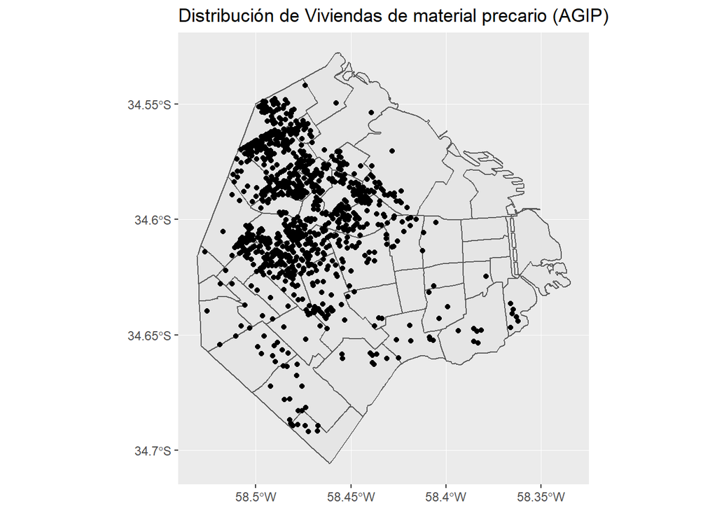

```r
ggplot() +
  geom_sf(data = barrios) +
  geom_sf(data = centr_mza_vmatp2) +
  labs(title = "Distribución de Viviendas de material precario (AGIP)")
```

**Paso 2: mapeo de ambas capas de información espacial**

Por último mapeamos las dos capas de información para analizarlas conjuntamente:

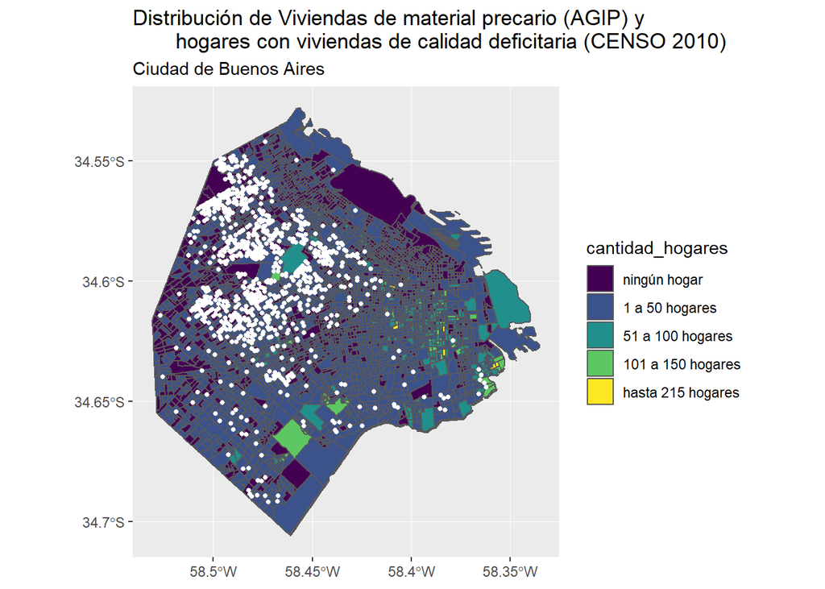

```r
ggplot() +
    geom_sf(data = CENSO_NO_VIV10, aes(fill = cantidad_hogares)) +
    geom_sf(data = centr_mza_vmatp2, color= "white", size=1) +
  labs(title = "Distribución de Viviendas de material precario (AGIP) y
       hogares con viviendas de calidad deficitaria (CENSO 2010)",
         subtitle = "Ciudad de Buenos Aires")
```

Antes de analizar los resultados obtenidos es importante detallar cuáles son los parámetros que deben cumplir las viviendas para ser categorizadas como *VIVIENDAS MATERIAL PRECARIO*, según **AGIP**, y **HOGARES CON VIVIENDAS DE CALIDAD DEFICITARIA**, en el caso de **INDEC**.

En cuanto a **AGIP**, las viviendas comprendidas dentro del destino constructivo MATERIAL PRECARIO se corresponden con aquellas cuyos materiales de construcción precarios (maderas, chapas de asbestos, cemento-plásticas o metálicas, mampostería escasa) y sistemas de fabricación conducen a que posean una vida útil limitada.

En cuanto a **INDEC**, las viviendas son catalogadas como del tipo VIVIENDAS DEFICITARIAS cuando cumplen las siguientes condiciones:

**Casa tipo B**: es la que cumple por lo menos una de las siguientes condiciones: no tiene provisión de agua por cañería dentro de la vivienda; no dispone de retrete con descarga de agua; tiene piso de tierra u otro material precario.

**Viviendas precarias**: incluye vivienda sin cañería de agua en su interior, tanto aquellas cuya provisión de agua es exterior a las mismas pero dentro del lote en que fueron construidas, así como también las que obtienen el agua fuera del lote. Ejemplos: piezas de inquilinato, ranchos, viviendas precarias (rancho, casilla), los hogares en casa de inquilinato, los locales no construidos para habitación y las viviendas móviles. No se consideran en esta categoría los hoteles y pensiones.

Si se realiza una comparación entre las categorías de AGIP y de INDEC en cuanto a la evaluación de la calidad de la vivienda se deduce que AGIP tiene en cuenta condiciones referentes a la construcción de la vivienda y el tipo de material empleado (aspectos externos) para determinar la precariedad de la vivienda. En cambio, INDEC analiza condiciones sanitarias al interior de la vivienda (provisión de agua por cañería, descarga de agua residual, piso interno de tierra) para designar si una vivienda es de tipo deficitaria o no.

Mediante la observación del mapa final **“Distribución de Viviendas de material precario (AGIP) y Hogares con viviendas de calidad deficitaria (CENSO 2010)”** podemos afirmar:

**Caso AGIP**: la distribución espacial de viviendas de material precario se analiza a nivel de manzana catastral (sm). En primera instancia se determinó, mediante la observación de la tabla de destinos constructivos, que existían pocos casos de viviendas de material precario por manzana (máximo 10 casos por manzana). Luego, observando la distribución espacial de las mismas en el mapa final puede decirse que la mayor concentración se encuentra hacia el oeste de la ciudad, mientras que hacia el sur y este se destaca un comportamiento bastante disperso. La falta de datos hacia el este y sur de la ciudad, donde se sabe que existen viviendas de material precario por la mayor concentración de villas y asentamientos, puede deberse a que los asentamientos no cuentan aún con parcelamiento en las manzanas y, consecuentemente, no poseen partida matriz parcelaria, necesaria para el cobro de rentas. De esta manera estos terrenos quedan fuera del registro de AGIP.

**Caso CENSO 2010**: en este caso el análisis de la distribución espacial de los hogares con viviendas de calidad deficitaria es a nivel de radio censal. Se observa una concentración marcada de valores altos en los barrios de La Boca, Villa Soldati, Villa Lugano, sur de Flores, Floresta, Retiro, Chacharita, Paternal, Barracas y el área de la Reserva Ecológica Costanera Sur. Estos valores altos son coherentes debido a que en estos barrios de la ciudad se encuentran villas y asentamientos precarios (villa 1-11-14, villa 21-24, villa 31, Rodrigo Bueno, villa 15, villa Fraga, La Carbonilla, entre otros).  
También se observa una alta concentración de valores altos en el microcentro y sectores aledaños (San Cristóbal, Montserrat, Constitución, San Telmo, Balvanera, Parque Patricios). Este patrón podría deberse a la existencia en estas zonas de conventillos e inquilinatos, la mayoría de los cuales presentan calidad deficitaria.

**Análisis comparativo de ambas distribuciones espaciales**

Antes de llevar a cabo este trabajo nos planteamos como objetivo analizar la relación entre la identificación tributaria de las viviendas de tipo precario y las viviendas caracterizadas como de calidad deficitaria por INDEC. Suponíamos previamente la existencia de cierta correspondencia entre ambos casos. Sin embargo, mediante el análisis de los resultados evidenciamos que los patrones de comportamiento son totalmente contrarios.

> CONCLUSIONES

Se determinó que los patrones de distribución espacial de las viviendas de material precario según AGIP presentan un comportamiento totalmente opuesto al de la distribución de hogares con viviendas de calidad deficitaria obtenidas del censo. Con este resultado obtenido nos planteamos el siguiente interrogante: AGIP está determinando, según su concepción, viviendas de material precario en áreas donde INDEC no registra hogares con viviendas de calidad deficitaria. Las viviendas de material precario poseen el menor puntaje de categoría, lo cual repercute en valores más bajos a tributar (inmobiliario y ABL). Esto conduce a pensar que la Ciudad aplica políticas tributarias en base a criterios constructivos externos sin tener en cuenta deficiencias al interior de la vivienda y hogares con altos niveles de NBI.

**Artículos y links consultados**

- Glosario INDEC (https://www.indec.gov.ar/textos_glosario.asp?id=70)
- Categorías de viviendas según AGIP (http://www.arete-pi.com.ar/pdf_pregfrec/Categorias%20Rentas%20.pdf)
- http://data.triviasp.com.ar/files/parte3/ragipgcba43511.htm
- https://data.buenosaires.gob.ar/